# Public Sentiment on the Use of Facial Recognition

by Anny-Claude Joseph

Last compiled on 14 August, 2020

### Background

In the past, facial recognition technology (FRT) was viewed as something straight out of science fiction. However, over the past decade, this technology has become viable and increasingly widespread. Recently, several lawmakers have expressed concern that certain groups are not using FRT responsibly. Let us examine public sentiment on this topic using a dataset based on a portion of the Pew Research Center’s American Trends Panel (Pew Research Center, 2019).[^1] The variables in the dataset are described in the table.

| Variable | Description |
| --- | --- |
| TrustAdvertisers | Do you trust advertisers to use facial recognition technology responsibly? |
| TrustTechCompany | Do you trust technology companies to use facial recognition technology responsibly? |
| TrustPolice | Do you trust law enforcement to use facial recognition technology responsibly? |
| Education | College Educated |
| Race | Race |

```r
library('tidyverse')
dat <- read_csv('C:/Users/annyclaude.joseph/Documents/Joseph_Teaching/AY21-1/MA376/Lectures/American Trends Panel/W49_Jun19/Wave49.csv')
# head(dat)
```

#### Step 1: Ask a research question

Write a research question involving two variables in the dataset.

*Is there an association between educational attainment and belief that law enforcement would use FRT responsibly?*

#### Step 2: Design a study and collect data

Use no more than three sentences to describe the data. Be sure to indicate how many subjects are in the analysis and what values the variables take on.

*Data were collected on 5,859 adults in the United States from June 3 to June 17, 2019. We used in our analysis n = 3,187 individuals with measurements for the following variables: TrustPolice (Not too much/No vs Yes/Somewhat) and Education (College vs No College).*

```r
# install.package(table1)
library('table1')
table1(~TrustPolice+Education, data = dat)
```

|  | Overall (N=3187) |
| --- | --- |
| TrustPolice |  |
| Not too much/No | 1016 (31.9%) |
| Yes/Somewhat | 2171 (68.1%) |
| Education |  |
| College | 1304 (40.9%) |
| No College | 1883 (59.1%) |

```r
# table(dat$TrustPolice)
# table(dat$Education)
```

#### Step 3: Explore the data

##### a. Create a bar graph of the response variable. Describe the plot.

*More than 2,000 adults agreed (Yes/Somewhat) that law enforcement could be trusted to use FRT responsibly while a little over 1,000 expressed more skepticism (Not too much/No)*.

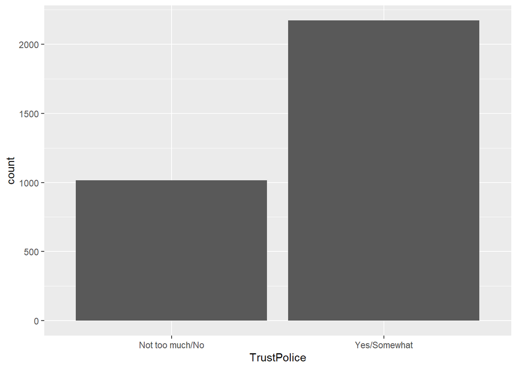

```r
# a. Bar graph
dat %>% ggplot(aes(TrustPolice))+ geom_histogram(stat='count')
```

##### b. Create a contingency table and mosaic plot to summarize the response and explanatory variables. Does the plot suggest an association exists? Explain.

*The plot shows that a higher proportion of individuals did not have a college education (59.1%), and higher proportion of individuals trusted law enforcement (68.1%). The percentage of individuals who trusted law enforcement was higher for non-college educated than college educated individuals (70.2% vs 65.2%).*

```r
# b. Contingency table
table1(~TrustPolice|Education, data = dat)
```

|  | College (N=1304) | No College (N=1883) | Overall (N=3187) |
| --- | --- | --- | --- |
| TrustPolice |  |  |  |
| Not too much/No | 454 (34.8%) | 562 (29.8%) | 1016 (31.9%) |
| Yes/Somewhat | 850 (65.2%) | 1321 (70.2%) | 2171 (68.1%) |

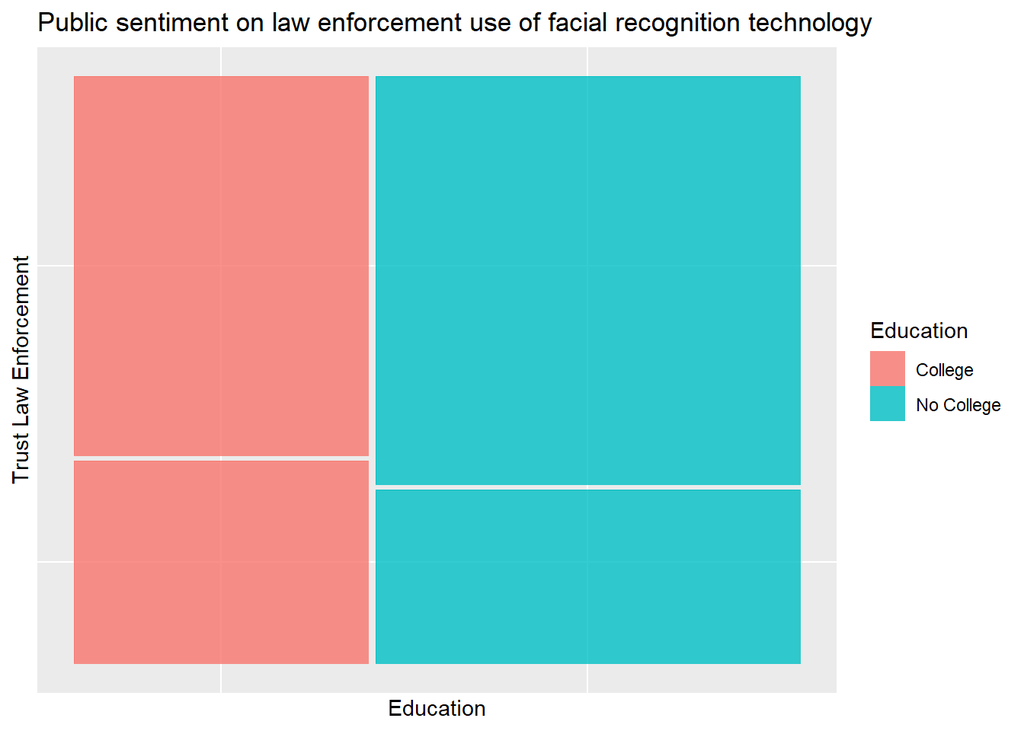

```r
# Mosaic plot
# install.package(ggmosaic)
library('ggmosaic')
dat %>% ggplot()+
  geom_mosaic(aes(x=product(TrustPolice,Education),fill=Education))+
  labs(title='Public sentiment on law enforcement use of facial recognition technology', y='Trust Law Enforcement', x='Education')
```

##### c. Identify a potential confounding variable and explain how it may be confounding in this study.

*Race is a potential confounder. Sentiments about law enforcement use of FRT and educational attainment may vary by race*.

##### d. Create another mosaic plot that includes the third variable. Does the plot suggest that the third variable is confounding? Explain.

*Race affected the association between educational attainment and belief that law enforcement would use FRT responsibly. A larger proportion of Whites trusted law enforcement regardless of educational attainment. However, for Blacks who were not college educated, the percentage of individuals who trusted law enforcement was higher than those who were more skeptical (55.8% vs 44.2%); whereas for Blacks who were college educated, the percentage of individuals who trusted law enforcement was lower (46.3% vs 53.7%).*

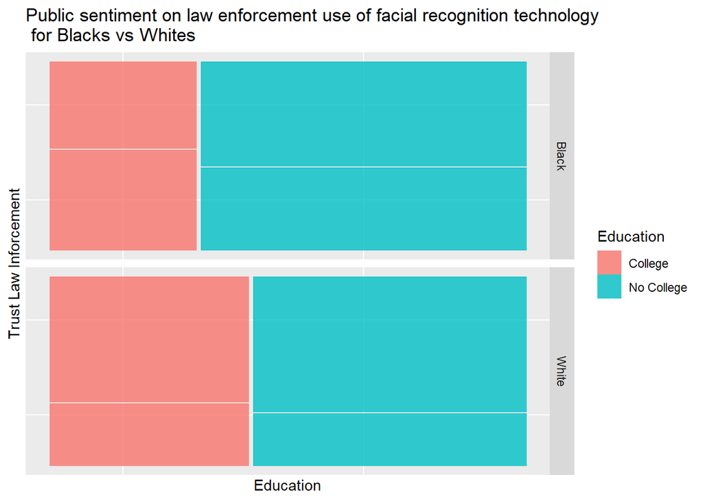

```r
# d. Mosaic plot that includes the third variable
dat %>% ggplot()+
  geom_mosaic(aes(x=product(TrustPolice,Education),fill=Education)) +
  labs(title='Public sentiment on law enforcement use of facial recognition technology \n for Blacks vs Whites', y='Trust Law Inforcement', x='Education')+
  facet_grid(Race~.)
```

```r
table1(~TrustPolice|Race*Education, data = dat)
```

|  | Black College (N=108) | Black No College (N=240) | White College (N=1196) | White No College (N=1643) | Overall College (N=1304) | Overall No College (N=1883) |
| --- | --- | --- | --- | --- | --- | --- |
| TrustPolice |  |  |  |  |  |  |
| Not too much/No | 58 (53.7%) | 106 (44.2%) | 396 (33.1%) | 456 (27.8%) | 454 (34.8%) | 562 (29.8%) |
| Yes/Somewhat | 50 (46.3%) | 134 (55.8%) | 800 (66.9%) | 1187 (72.2%) | 850 (65.2%) | 1321 (70.2%) |

##### e. Construct the Sources of Variation Diagram:[^2]

| Observed variation in: | Sources of explained variation: | Sources of unexplained variation: |
| --- | --- | --- |
| Trust law enforcement | Education | Age |
|  | Race | Political affiliation |
| Inclusion criteria: |  | Unknown |
| U.S. adults |  |  |

#### Step 4: Draw inferences beyond the data

Name one theory-based approach we could use to determine if there was a statistically significant difference between the levels of the explanatory variable.

*Two-sample z-test could be used to see if belief that law enforcement would use FRT responsibly differs between college educated and non-college educated individuals.*

#### Step 5: Formulate conclusions

How far can we generalize our conclusions? Could we draw a cause-effect conclusion if we observed statistically significant differences in Step 4? Why or why not?

*We should be cautious about generalizing to the entire U.S. adult population. Although a representative sample was surveyed in the original Pew study, this analysis was restricted to two races. Additionally, we would not be able to make a cause-effect conclusion because this is not a randomized experiment.*

#### Step 6: Look back and ahead

What are two limitations to our approach? Discuss how we could address these limitations in a future study.

*In future work we could create statistical models that allow us to 1) adjust for categorical variables with more than two levels and 2) evaluate the impact of potential confounders like socioeconomic status and political party affiliation .*

### Further Investigation

Work with a partner to investigate another response variable. Are your conclusions consistent with this analysis?

### References

Pew Research Center. American Trends Panel Wave 49. https://www.pewresearch.org/internet/dataset/american-trends-panel-wave-49/ (2019). Accessed: 2020-08-12.

[^1]: All variable modifications are documented [here](https://github.com/tooderful/MA376/tree/master/LSN%201/Prep%20Files). Additional information about the Pew study can be found in the ATP W49 methodology pdf.
[^2]: A convenient table generator can be found [here](https://www.tablesgenerator.com/latex_tables).